# Lab 6 Regression Models

## 6.1 Fitting a Regression Model

We shall make use of

- `ape`, which is one of several packages that contain functionality for testing spatial or spatio-temporal independence with Moran’s I statistic;
- `FRK`, which contains functionality for constructing the basis functions

```r
library("ape")
library("FRK")
library("lattice")
library("RColorBrewer")
library("gstat")
library("sp")
library("spacetime")
library("STRbook")
library("tidyverse")
```

We again consider the NOAA data set, specifically the maximum temperature data for the month of July 1993. These data can be extracted as follows.

```r
data("NOAA_df_1990", package = "STRbook")
Tmax <- filter(NOAA_df_1990, # subset the data
               proc == "Tmax" & # only max temperature
                 month == 7 & # July
                 year == 1993) # year of 1993
```

The linear model we fit has the following form, with the list of basis functions:

$$Z(\textbf{s}_i,t_j) = \beta_0 + \beta_1X_1(\textbf{s}_i,t_j) + \cdots +
\beta_p X_p(\textbf{s}_i,t_j) + e(\textbf{s}_i,t_j)$$
The set of basis functions can be constructed using the function `auto_basis` in FRK. The function takes as arguments data, which is a spatial object; `nres`, which is the number of “resolutions” to construct; and `type`, which indicates the type of basis function to use.

```r
G <- auto_basis(data = Tmax[,c("lon","lat")] %>% # Take Tmax
                  SpatialPoints(), # To sp obj
                nres = 1, # One resolution
                type = "Gaussian") # Gaussian BFs
```

These basis functions evaluated at data locations are then the covariates we seek for fitting the data. The functions are evaluated at any arbitrary location using the function `eval_basis`. This function requires the locations as a matrix object, and it returns the evaluations as an object of class `Matrix`, which can be easily converted to a `matrix` as follows.

```r
S <- eval_basis(basis = G, # basis functions
                s = Tmax[,c("lon","lat")] %>% # spat locations
                  as.matrix()) %>% # conv. to matrix
  as.matrix() # results as matrix

colnames(S) <- paste0("B", 1:ncol(S)) # assign column names
```

When fitting the linear model we shall use the convenient notation “.” to denote “all variables in the data frame” as covariates. This is particularly useful when we have many covariates, such as the 12 basis functions above. Therefore, we first remove all variables (except the field `id` that we shall omit manually later) that we do not wish to include in the model, and we save the resulting data frame as `Tmax2`.

```r
Tmax2 <- cbind(Tmax, S) %>% # append S to Tmax
  select(-year, -month, -proc, # and remove vars we
         -julian, -date) # will not be using in
                          # the model
Tmax2
```

| day | id | z | lat | lon | B1 | B2 | B3 | B4 | B5 | B6 | B7 | B8 | B9 | B10 | B11 | B12 |
| --- | --- | --- | --- | --- | --- | --- | --- | --- | --- | --- | --- | --- | --- | --- | --- | --- |
| 1 | 3804 | 82 | 39.35000 | -81.43333 | 0.002876094 | 0.05719898 | 0.30812839 | 0.449607294 | 0.006202851 | 0.12336061 | 0.6645381 | 0.969664597 | 0.0033155913 | 0.065939578 | 0.355213590 | 0.5183119345 |
| 2 | 3804 | 84 | 39.35000 | -81.43333 | 0.002876094 | 0.05719898 | 0.30812839 | 0.449607294 | 0.006202851 | 0.12336061 | 0.6645381 | 0.969664597 | 0.0033155913 | 0.065939578 | 0.355213590 | 0.5183119345 |
| 3 | 3804 | 88 | 39.35000 | -81.43333 | 0.002876094 | 0.05719898 | 0.30812839 | 0.449607294 | 0.006202851 | 0.12336061 | 0.6645381 | 0.969664597 | 0.0033155913 | 0.065939578 | 0.355213590 | 0.5183119345 |
| 4 | 3804 | 90 | 39.35000 | -81.43333 | 0.002876094 | 0.05719898 | 0.30812839 | 0.449607294 | 0.006202851 | 0.12336061 | 0.6645381 | 0.969664597 | 0.0033155913 | 0.065939578 | 0.355213590 | 0.5183119345 |
| 5 | 3804 | 92 | 39.35000 | -81.43333 | 0.002876094 | 0.05719898 | 0.30812839 | 0.449607294 | 0.006202851 | 0.12336061 | 0.6645381 | 0.969664597 | 0.0033155913 | 0.065939578 | 0.355213590 | 0.5183119345 |
| 6 | 3804 | 91 | 39.35000 | -81.43333 | 0.002876094 | 0.05719898 | 0.30812839 | 0.449607294 | 0.006202851 | 0.12336061 | 0.6645381 | 0.969664597 | 0.0033155913 | 0.065939578 | 0.355213590 | 0.5183119345 |
| 7 | 3804 | 92 | 39.35000 | -81.43333 | 0.002876094 | 0.05719898 | 0.30812839 | 0.449607294 | 0.006202851 | 0.12336061 | 0.6645381 | 0.969664597 | 0.0033155913 | 0.065939578 | 0.355213590 | 0.5183119345 |
| 8 | 3804 | 94 | 39.35000 | -81.43333 | 0.002876094 | 0.05719898 | 0.30812839 | 0.449607294 | 0.006202851 | 0.12336061 | 0.6645381 | 0.969664597 | 0.0033155913 | 0.065939578 | 0.355213590 | 0.5183119345 |
| 9 | 3804 | 96 | 39.35000 | -81.43333 | 0.002876094 | 0.05719898 | 0.30812839 | 0.449607294 | 0.006202851 | 0.12336061 | 0.6645381 | 0.969664597 | 0.0033155913 | 0.065939578 | 0.355213590 | 0.5183119345 |
| 10 | 3804 | 93 | 39.35000 | -81.43333 | 0.002876094 | 0.05719898 | 0.30812839 | 0.449607294 | 0.006202851 | 0.12336061 | 0.6645381 | 0.969664597 | 0.0033155913 | 0.065939578 | 0.355213590 | 0.5183119345 |

[output cut: 990 more lines]

We also remove 14 July 1993 to see how predictions on this day are affected, given that we have no data on that day.

```r
Tmax_no_14 <- filter(Tmax2, !(day == 14)) # remove day 14
```

We now fit the linear model using lm. The formula we use is `z ~ (lon + lat + day)^2 + .` which indicates that we have as covariates longitude, latitude, day, and all the interactions between them, as well as the other covariates in the data frame (the 12 basis functions) without interactions.

```r
Tmax_July_lm <- lm(z ~ (lon + lat + day)^2 + ., # model
data = select(Tmax_no_14, -id)) # omit id
```

The results of this fit can be viewed using `summary`.

```r
Tmax_July_lm %>% summary()
```

```
Call:
lm(formula = z ~ (lon + lat + day)^2 + ., data = select(Tmax_no_14,
    -id))

Residuals:
     Min       1Q   Median       3Q      Max
-17.5136  -2.4797   0.1098   2.6644  14.1659

Coefficients:
              Estimate Std. Error t value Pr(>|t|)
(Intercept) 192.243242  97.854126   1.965 0.049531 *
lon           1.756918   1.088175   1.615 0.106486
lat          -1.317402   2.555626  -0.515 0.606239
day          -1.216456   0.133547  -9.109  < 2e-16 ***
B1           16.646617   4.832399   3.445 0.000577 ***
B2           18.528159   3.056082   6.063 1.46e-09 ***
B3           -6.606896   3.171759  -2.083 0.037312 *
B4           30.545361   4.369591   6.990 3.20e-12 ***
B5           14.739147   2.746866   5.366 8.52e-08 ***
B6          -17.541177   3.423081  -5.124 3.13e-07 ***
B7           28.472198   3.551900   8.016 1.42e-15 ***
B8          -27.348145   3.164317  -8.643  < 2e-16 ***
B9          -10.234777   4.456735  -2.296 0.021701 *
B10          10.558234   3.327370   3.173 0.001519 **
B11         -22.757661   3.532508  -6.442 1.32e-10 ***
B12          21.864383   4.812940   4.543 5.72e-06 ***
lon:lat      -0.026021   0.028232  -0.922 0.356755
lon:day      -0.022696   0.001288 -17.615  < 2e-16 ***
lat:day      -0.019032   0.001876 -10.147  < 2e-16 ***
---
Signif. codes:  0 ‘***’ 0.001 ‘**’ 0.01 ‘*’ 0.05 ‘.’ 0.1 ‘ ’ 1

Residual standard error: 4.225 on 3970 degrees of freedom
Multiple R-squared:  0.7023,    Adjusted R-squared:  0.701
F-statistic: 520.4 on 18 and 3970 DF,  p-value: < 2.2e-16
```

### 6.1.1 Analyzing the Residuals

Having fitted a spatio-temporal model, it is good practice to check the residuals.

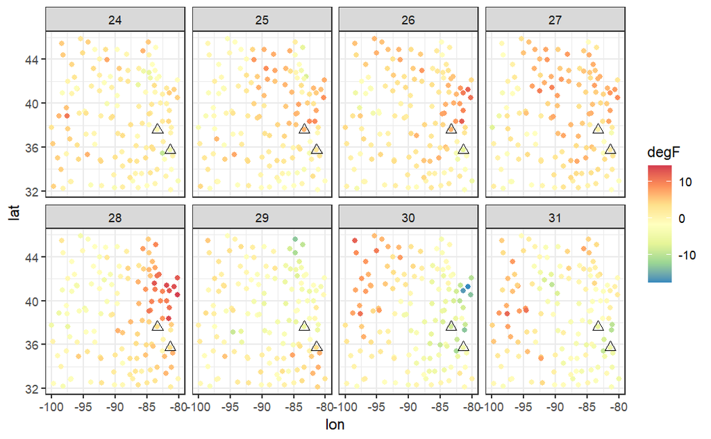

```r
Tmax_no_14$residuals <- residuals(Tmax_July_lm)

g <- ggplot(filter(Tmax_no_14, day %in% 24:31)) +
  geom_point(aes(lon, lat, colour = residuals)) +
  facet_wrap(~ day, ncol=4) +
  col_scale(name = "degF") +
  geom_point(data = filter(Tmax_no_14,day %in% 24:31 &
                             id %in% c(3810, 3889)),
             aes(lon, lat), colour = "black",
             pch = 2, size = 2.5) +
  theme_bw()

g
```

Notice how these residuals are strongly spatially correlated.

When the data are regularly spaced in time, as is the case here, one may also look at the “temporal” residuals at some location. For example, consider the maximum temperature (`Tmax`) residuals at stations 3810 and 3889.

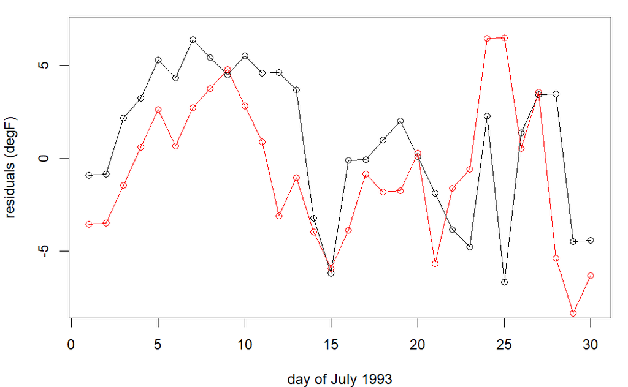

```r
TS1 <- filter(Tmax_no_14, id == 3810)$residuals
TS2 <- filter(Tmax_no_14, id == 3889)$residuals

par(mar=c(4, 4, 1, 1))
plot(TS1, # Station 3810 residuals
     xlab = "day of July 1993",
     ylab = "residuals (degF)",
     type = 'o', ylim = c(-8, 7))
lines(TS2, # Station 3889 residuals
      xlab = "day of July 1993",
      ylab = "residuals (degF)",
      type = 'o', col = "red")
```

Note that there is clear temporal correlation in the residuals; that is, residuals close to each other in time tend to be more similar than residuals further apart. It is also interesting to note that the residuals are correlated between the stations; that is, at the same time point, the residuals at both stations are more similar than at different time points.

### 6.1.2 Predictions

Prediction from linear linear models in R is carried out using the function predict. We use the following prediction grid.

```r
pred_grid <- expand.grid(lon = seq(-100, -80, length = 20),
                         lat = seq(32, 46, length = 20),
                         day = seq(4, 29, length = 6))
```

We require all the covariate values at all the prediction locations. Hence, the 12 basis functions need to be evaluated on this grid. As above, we do this by calling `eval_basis` and converting the result to a matrix, which we then attach to our prediction grid.

```r
Spred <- eval_basis(basis = G, # basis functs
                    s = pred_grid[,c("lon","lat")] %>% # pred locs
                      as.matrix()) %>% # conv. to matrix
  as.matrix() # results as matrix

colnames(Spred) <- paste0("B", 1:ncol(Spred)) # assign col names
pred_grid <- cbind(pred_grid, Spred) # attach to grid
```

We can use Moran’s I test to test for spatial dependence in the residuals on each day. In the following code, we take each day in our data set, compute the distances, form the weight matrix, and carry out Moran’s I test using the function `Moran.I` from the package `ape`.

```r
P <- list() # init list
days <- c(1:13, 15:31) # set of days
for(i in seq_along(days)) { # for each day
  Tmax_day <- filter(Tmax_no_14,
                     day == days[i]) # filter by day
  station.dists <- Tmax_day %>% # take the data
    select(lon, lat) %>% # extract coords.
    dist() %>% # comp. dists.
    as.matrix() # conv. to matrix
  station.dists.inv <- 1/station.dists # weight matrix
  diag(station.dists.inv) <- 0 # 0 on diag
  P[[i]] <- Moran.I(Tmax_day$residuals, # run Moran's I
                    station.dists.inv) %>%
    do.call("cbind", .) # conv. to df
}

do.call("rbind", P) %>% head()
```

```
      observed     expected         sd p.value
[1,] 0.2716679 -0.007575758 0.01235583       0
[2,] 0.2264147 -0.007575758 0.01236886       0
[3,] 0.2113966 -0.007575758 0.01236374       0
[4,] 0.1626477 -0.007575758 0.01238872       0
[5,] 0.2580333 -0.007575758 0.01241006       0
[6,] 0.1216741 -0.007575758 0.01227211       0
```

```r
linreg_pred <- predict(Tmax_July_lm,
                       newdata = pred_grid,
                       interval = "prediction")

## Assign prediction to the prediction grid
pred_grid$z_pred <- linreg_pred[,1]
```

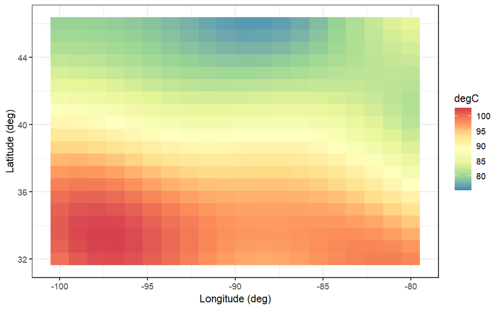

```r
ggplot(pred_grid) +
  geom_tile(aes(x=lon,y=lat,fill=z_pred)) +
  fill_scale(name = "degC") + theme_bw() +
  xlab("Longitude (deg)") + ylab("Latitude (deg)")
```

```r
  facet_wrap(~day)
```

[output not shown]

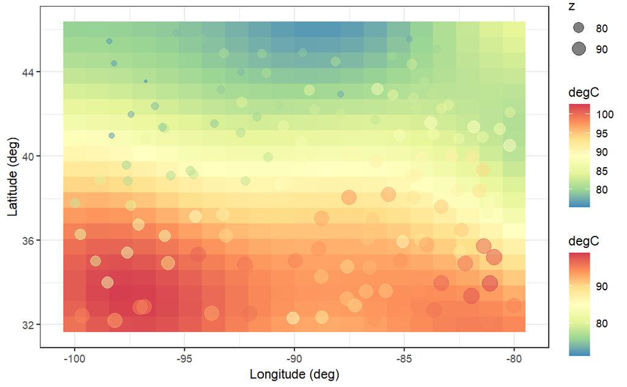

```r
Tmax_14 <- filter(Tmax2, day == 14) # remove day 14

ggplot() +
  geom_tile(data=pred_grid, aes(x=lon,y=lat,fill=z_pred)) +
  geom_point(data=Tmax_14, aes(x=lon,y=lat,col=z, size=z), alpha=0.5) +
  col_scale(name = "degC")+
  fill_scale(name = "degC") + theme_bw() +
  xlab("Longitude (deg)") + ylab("Latitude (deg)")
```

```r
  facet_wrap(~day)
```

[output not shown]

## 6.2 Single Pixel Regression

We fit a simple linear model to every pixel in the SST data set, and we use these models to predict SST for a month in which we have no SST data. The models will simply contain an intercept and a single covariate, namely the Southern Oscillation Index (SOI). The SOI data we use here are supplied with `STRbook`.

The first task in this Lab is to wrangle the SST data into a long-format data frame that is amenable to linear fitting and plotting. The SST data are provided in three data frames, one describing the land mask, one containing the SST values in wide format, and one containing the coordinates.

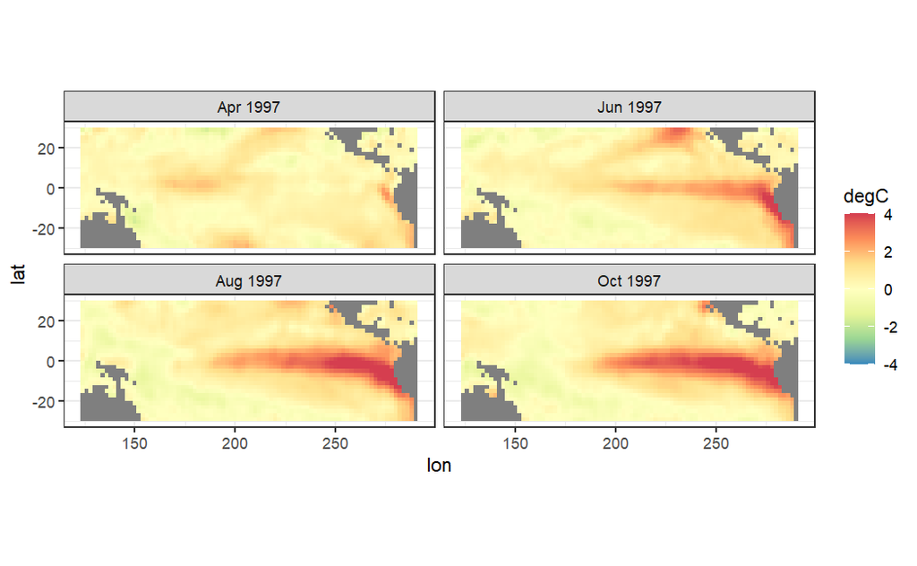

```r
data("SST_df", package = "STRbook")

g <- ggplot(filter(SST_df, Year == 1997 & # subset by month/year
                     Month %in% c("Apr","Aug","Jun","Oct"))) +
  geom_tile(aes(lon, lat,
                fill = pmin(sst, 4))) + # clamp SST at 4deg
  facet_wrap(~date, dir = "v") + # facet by date
  fill_scale(limits = c(-4, 4), # color limits
             name = "degC") + # legend title
  theme_bw() + coord_fixed() # fix scale and theme
g
```

### 6.2.1 Fitting the Models Pixelwise

We fit linear time-series models to the SSTs in each pixel using data up to April 1997. We first create a data frame containing the SST data between January 1970 and April 1997.

```r
SST_pre_May <- filter(SST_df, Year <= 1997) %>%
  filter(!(Year == 1997 &
             Month %in% c("May", "Jun", "Jul",
                          "Aug", "Sep", "Oct",
                          "Nov", "Dec")))
```

```r
library(purrr)
library(broom)

fit_one_pixel <- function(data)
  mod <- lm(sst ~ 1 + soi, data = data)

pixel_lms <- SST_pre_May %>%
  filter(!is.na(sst)) %>%
  group_by(lon, lat) %>%
  nest() %>%
  mutate(model = map(data, fit_one_pixel)) %>%
  mutate(model_df = map(model, tidy))

pixel_lms %>% head(3)
```

| lon | lat | data | model | model_df |
| --- | --- | --- | --- | --- |
| 154 | -29 |  |  |  |
| 156 | -29 |  |  |  |
| 158 | -29 |  |  |  |

To extract the model parameters from the linear-fit data frames, we use `unnest`:

```r
lm_pars <- pixel_lms %>%
unnest(model_df)
```

For each pixel, we now have an estimate of the intercept and the effect associated with the covariate `soi`:

```r
head(lm_pars, 3)
```

| lon | lat | data | model | term | estimate | std.error | statistic | p.value |
| --- | --- | --- | --- | --- | --- | --- | --- | --- |
| 154 | -29 |  |  | (Intercept) | 0.13220578 | 0.02664299 | 4.962122 | 1.125272e-06 |
| 154 | -29 |  |  | soi | 0.02768654 | 0.02231645 | 1.240633 | 2.156333e-01 |
| 156 | -29 |  |  | (Intercept) | 0.03652717 | 0.02617271 | 1.395621 | 1.637786e-01 |

We can plot spatial maps of the intercept and the regression coefficient associated with soi directly. We first merge this data frame with the coordinates data frame using `left_join`, which also contains land pixels. In this way, regression coefficients over land pixels are marked as NA, which is appropriate.

```r
data("SSTlandmask", package = "STRbook")
data("SSTdata", package = "STRbook")
data("SSTlonlat", package = "STRbook")
lonlatmask_df <- data.frame(cbind(SSTlonlat, SSTlandmask))
names(lonlatmask_df) <- c("lon", "lat", "mask")
```

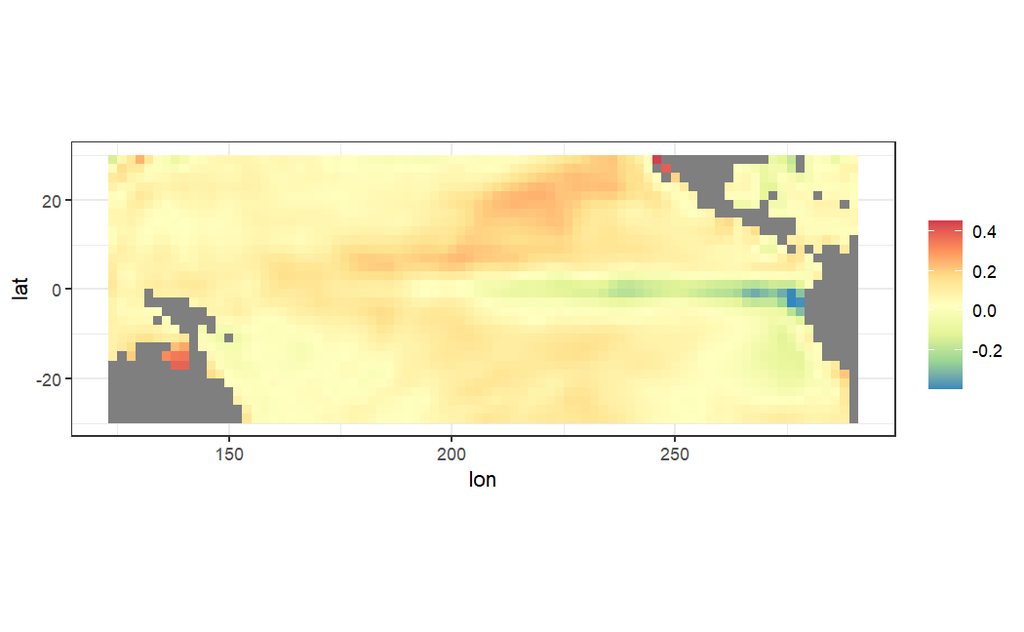

```r
lm_pars <- left_join(lonlatmask_df, lm_pars)

g2 <- ggplot(filter(lm_pars, term == "(Intercept)" | mask == 1)) +
geom_tile(aes(lon, lat, fill = estimate)) +
fill_scale() +
theme_bw() + coord_fixed()
g3 <- ggplot(filter(lm_pars, term == "soi" | mask == 1)) +
geom_tile(aes(lon, lat, fill = estimate)) +
fill_scale() +
theme_bw() + coord_fixed()

g2
```

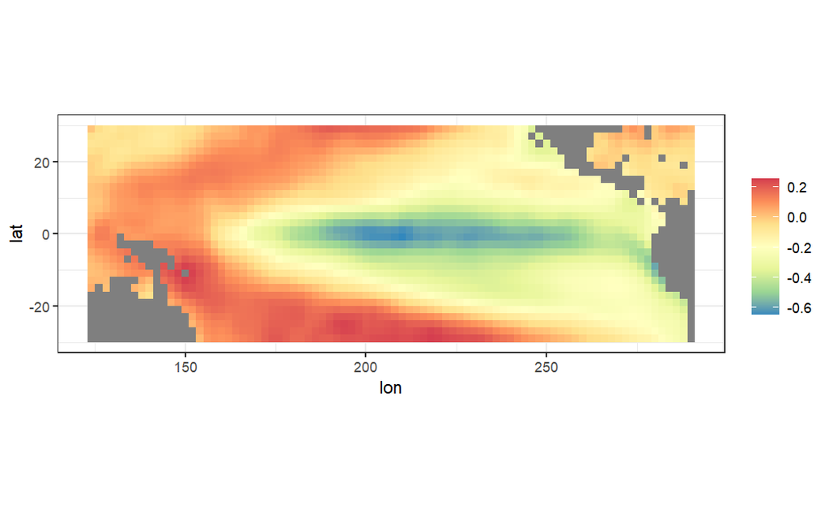

```r
g3
```

### 6.2.2 Predicting SST Pixelwise

s We now use the linear models at the pixel level to predict the SST in October 1997 using the SOI index for that month. The SOI for that month is extracted from `SOI_df` as follows.

```r
data("SOI", package = "STRbook")
SOI_df <- select(SOI, -Ann) %>% gather(Month, soi, -Year)

soi_pred <- filter(SOI_df, Month == "Oct" & Year == "1997") %>%
select(soi)
```

We next define the function that carries out the prediction at the pixel level. The function takes a linear model `lm` and the SOI at the prediction date `soi_pred`, runs the `predict` function for this date, and returns a data frame containing the prediction.

```r
predict_one_pixel <- function(lm, soi_pred) {
  predict(lm, # linear model
          newdata = soi_pred, # pred. covariates
          interval = "prediction") %>% # output intervals
    data.frame() %>% # convert to df
    mutate(se = (upr-lwr)/(2 * 1.96)) %>% # comp pred. se
    select(fit, se) # return fit & se
}

SST_Oct_1997 <- pixel_lms %>%
  mutate(preds = map(model,
                     predict_one_pixel,
                     soi_pred = soi_pred)) %>%
  unnest(preds)
```

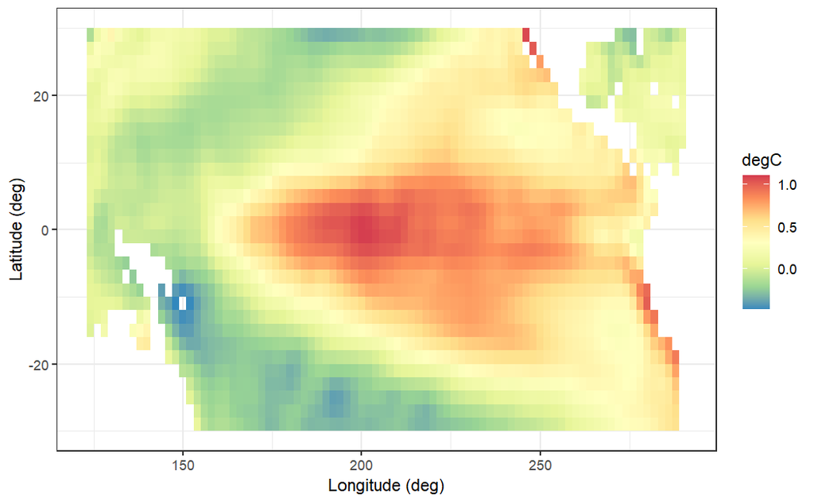

```r
ggplot(SST_Oct_1997) +
  geom_tile(aes(x=lon,y=lat,fill=fit)) +
  fill_scale(name = "degC") + theme_bw() +
  xlab("Longitude (deg)") + ylab("Latitude (deg)")
```

```r
  facet_wrap(~day)
```

[output not shown]